# Voltando um pouco no tempo...

Este projeto foi apresentado na disciplina de Laboratório de Redes em 2018, onde o desafio era criar uma análise de dados simples, coletando dados de alguma base, com uma conclusão e usabilidade no final.

Seguem os detalhes do projeto:

# Análise dos dados do YouTube

[figure not shown]

##### Autor:

- Almir Giornes (almirgiornes@gmail.com)

## Bibliotecas Utilizadas

Para elaborar a análise dos dados do YouTube, utilizei a [linguagem de programação Python](https://www.python.org/) em conjunto com outras bibliotecas específicas para visualização e análise de dados. Abaixo constam todas as bibliotecas utilizadas nesse projeto:

- [Pandas](https://pandas.pydata.org/);
- [Matplotlib](https://matplotlib.org/);
- [NumPy](http://www.numpy.org/);

```python
import pandas as pd
import matplotlib.pyplot as plt
import numpy as np
%matplotlib inline
```

## Lendo os dados extraídos

```python
usvideos = pd.read_csv("../data/USvideos.csv")
```

## Observando os dados

Essa etapa é a mais importante, pois é nela que será possível identificar a característica principal dos dados, que é a estrutura dos dados. A estrutura de um dataframe(ou camada de dados) nada mais é do que os tipos de variáveis dos dados que compõem o dataframe e "o que" ele nos informa de forma explícita. Na linha de comando abaixo, o __head__ serve para mostrar as 5 primeiras linhas do dataframe. Desse modo, fica mais fácil verificar quais informações cada coluna nos traz e os tipos de dados que iremos tratar.

```python
usvideos.head()
```

|  | video_id | trending_date | title | channel_title | category_id | publish_time | tags | views | likes | dislikes | comment_count | thumbnail_link | comments_disabled | ratings_disabled | video_error_or_removed | description |
| --- | --- | --- | --- | --- | --- | --- | --- | --- | --- | --- | --- | --- | --- | --- | --- | --- |
| 0 | 2kyS6SvSYSE | 17.14.11 | WE WANT TO TALK ABOUT OUR MARRIAGE | CaseyNeistat | 22 | 2017-11-13T17:13:01.000Z | SHANtell martin | 748374 | 57527 | 2966 | 15954 | https://i.ytimg.com/vi/2kyS6SvSYSE/default.jpg | False | False | False | SHANTELL'S CHANNEL - https://www.youtube.com/s... |
| 1 | 1ZAPwfrtAFY | 17.14.11 | The Trump Presidency: Last Week Tonight with J... | LastWeekTonight | 24 | 2017-11-13T07:30:00.000Z | last week tonight trump presidency\|"last week ... | 2418783 | 97185 | 6146 | 12703 | https://i.ytimg.com/vi/1ZAPwfrtAFY/default.jpg | False | False | False | One year after the presidential election, John... |
| 2 | 5qpjK5DgCt4 | 17.14.11 | Racist Superman \| Rudy Mancuso, King Bach & Le... | Rudy Mancuso | 23 | 2017-11-12T19:05:24.000Z | racist superman\|"rudy"\|"mancuso"\|"king"\|"bach"... | 3191434 | 146033 | 5339 | 8181 | https://i.ytimg.com/vi/5qpjK5DgCt4/default.jpg | False | False | False | WATCH MY PREVIOUS VIDEO ▶ \n\nSUBSCRIBE ► http... |
| 3 | puqaWrEC7tY | 17.14.11 | Nickelback Lyrics: Real or Fake? | Good Mythical Morning | 24 | 2017-11-13T11:00:04.000Z | rhett and link\|"gmm"\|"good mythical morning"\|"... | 343168 | 10172 | 666 | 2146 | https://i.ytimg.com/vi/puqaWrEC7tY/default.jpg | False | False | False | Today we find out if Link is a Nickelback amat... |
| 4 | d380meD0W0M | 17.14.11 | I Dare You: GOING BALD!? | nigahiga | 24 | 2017-11-12T18:01:41.000Z | ryan\|"higa"\|"higatv"\|"nigahiga"\|"i dare you"\|"... | 2095731 | 132235 | 1989 | 17518 | https://i.ytimg.com/vi/d380meD0W0M/default.jpg | False | False | False | I know it's been a while since we did this sho... |

O __dtypes__ informa os tipos de dados que cada coluna possui.

```python
usvideos.dtypes
```

```
video_id                  object
trending_date             object
title                     object
channel_title             object
category_id                int64
publish_time              object
tags                      object
views                      int64
likes                      int64
dislikes                   int64
comment_count              int64
thumbnail_link            object
comments_disabled           bool
ratings_disabled            bool
video_error_or_removed      bool
description               object
dtype: object
```

## Formatando datas

Ao analizar o dataframe, é possível observar que existem dados que são, de certa forma, confusos para visualizar.

Na situação da linha abaixo, é feita a formatação das datas de publicação do vídeo (localizada na coluna "publish_time") através da biblioteca Pandas.

```python
usvideos['trending_date']= pd.to_datetime(usvideos['trending_date'],format='%y.%d.%m')
usvideos['publish_time'] = pd.to_datetime(usvideos['publish_time'], format='%Y-%m-%dT%H:%M:%S.%fZ')
usvideos.head()
```

|  | video_id | trending_date | title | channel_title | category_id | publish_time | tags | views | likes | dislikes | comment_count | thumbnail_link | comments_disabled | ratings_disabled | video_error_or_removed | description |
| --- | --- | --- | --- | --- | --- | --- | --- | --- | --- | --- | --- | --- | --- | --- | --- | --- |
| 0 | 2kyS6SvSYSE | 2017-11-14 | WE WANT TO TALK ABOUT OUR MARRIAGE | CaseyNeistat | 22 | 2017-11-13 17:13:01 | SHANtell martin | 748374 | 57527 | 2966 | 15954 | https://i.ytimg.com/vi/2kyS6SvSYSE/default.jpg | False | False | False | SHANTELL'S CHANNEL - https://www.youtube.com/s... |
| 1 | 1ZAPwfrtAFY | 2017-11-14 | The Trump Presidency: Last Week Tonight with J... | LastWeekTonight | 24 | 2017-11-13 07:30:00 | last week tonight trump presidency\|"last week ... | 2418783 | 97185 | 6146 | 12703 | https://i.ytimg.com/vi/1ZAPwfrtAFY/default.jpg | False | False | False | One year after the presidential election, John... |
| 2 | 5qpjK5DgCt4 | 2017-11-14 | Racist Superman \| Rudy Mancuso, King Bach & Le... | Rudy Mancuso | 23 | 2017-11-12 19:05:24 | racist superman\|"rudy"\|"mancuso"\|"king"\|"bach"... | 3191434 | 146033 | 5339 | 8181 | https://i.ytimg.com/vi/5qpjK5DgCt4/default.jpg | False | False | False | WATCH MY PREVIOUS VIDEO ▶ \n\nSUBSCRIBE ► http... |
| 3 | puqaWrEC7tY | 2017-11-14 | Nickelback Lyrics: Real or Fake? | Good Mythical Morning | 24 | 2017-11-13 11:00:04 | rhett and link\|"gmm"\|"good mythical morning"\|"... | 343168 | 10172 | 666 | 2146 | https://i.ytimg.com/vi/puqaWrEC7tY/default.jpg | False | False | False | Today we find out if Link is a Nickelback amat... |
| 4 | d380meD0W0M | 2017-11-14 | I Dare You: GOING BALD!? | nigahiga | 24 | 2017-11-12 18:01:41 | ryan\|"higa"\|"higatv"\|"nigahiga"\|"i dare you"\|"... | 2095731 | 132235 | 1989 | 17518 | https://i.ytimg.com/vi/d380meD0W0M/default.jpg | False | False | False | I know it's been a while since we did this sho... |

## Exibindo informações dos dados

As colunas passaram pela formatação no formato de data do Pandas e, para conferir os resultados, pode-se utilizar do comando "[dataframe].info()". Com essa formatação, a manipulação das datas fica ainda mais fácil.

```python
usvideos.info()
```

```
<class 'pandas.core.frame.DataFrame'>
RangeIndex: 40949 entries, 0 to 40948
Data columns (total 16 columns):
video_id                  40949 non-null object
trending_date             40949 non-null datetime64[ns]
title                     40949 non-null object
channel_title             40949 non-null object
category_id               40949 non-null int64
publish_time              40949 non-null datetime64[ns]
tags                      40949 non-null object
views                     40949 non-null int64
likes                     40949 non-null int64
dislikes                  40949 non-null int64
comment_count             40949 non-null int64
thumbnail_link            40949 non-null object
comments_disabled         40949 non-null bool
ratings_disabled          40949 non-null bool
video_error_or_removed    40949 non-null bool
description               40379 non-null object
dtypes: bool(3), datetime64[ns](2), int64(5), object(6)
memory usage: 4.2+ MB
```

## Inserindo novas colunas e organizando os dados

Para organizar melhor os dados, foi criada 4 novas colunas, compostas pelo ano da publicação ("publish_year"), mês da publicação ("publish_month"), dia da publicação ("publish_day"), e hora da publicação ("publish_hour"). Com essa organização, é possível elaborar análises mais concisas e precisas, utilizando hora da publicação como padrão, ou mais gerais, utilizando uma escala de meses, sem muitas complicações.

```python
usvideos['publish_year']= usvideos['publish_time'].dt.year
usvideos['publish_month']= usvideos['publish_time'].dt.month
usvideos['publish_day']= usvideos['publish_time'].dt.day
usvideos['publish_hour']= usvideos['publish_time'].dt.hour
usvideos
```

[output not shown]

40949 rows × 20 columns

```python
metrics = ['likes','views','comment_count','dislikes']

grp_title = usvideos.groupby('title')[metrics].sum()
grp_title.reset_index(inplace=True)

grp_cat = usvideos.groupby('category_id')[metrics].sum()
grp_cat.reset_index(inplace=True)
```

A função __groupby__ do Pandas, nesse caso, irá agrupar o título em conjunto com os valores das métricas. Assim, será possível identificar qual vídeo com um determinado título têm de likes, views, comentários e dislikes.

```python
likes = grp_title.sort_values('likes',ascending=True)
likes.reset_index(inplace=True)

views = grp_title.sort_values('views',ascending=True)
views.reset_index(inplace=True)
print(views)


dislikes = grp_title.sort_values('dislikes',ascending=True)
dislikes.reset_index(inplace=True)


comment_count = grp_title.sort_values('comment_count',ascending=True)
comment_count.reset_index(inplace=True)
```

```
      index                                              title     likes  \
0      4376     Raw: 3 South Carolina Deputies, 1 Officer Shot         9
1      2513             Huffy Metaloid Bicycle Commercial 1997         2
2      5190  The Algorithm That Will Keep You Buying On Cyb...        35
3      1176      Coach Taggart Monday Presser Ahead of Arizona        20
4      2377          How Noah Galvin Makes Evan Hansen His Own        20
5        75   1 dead, others injured after Ky. school shooting        27
6      4058  OjO Commuter Scooter®- Light Electric Vehicle ...         6
7      3625   Martial Art Grandmaster Does Push ups Hands Free        17
8      1360  Danny Masterson Fired From Netflix Series 'The...        14
9      4463                          Road Rage - Russian Style         6
10     4844                Sphaera - demonstrating interaction         3
11     4327                  RAPID EYE MOVEMENT⎪Teaser Trailer         0
12     5524  This Is Us: Press Room Q&A | 24th Annual SAG A...        35
13      557                                      Artwork Forge         3
```

[output cut: 112 more lines]

# Visualizando os resultados

Com os resultados obtidos na etapa anterior, é possível obter a visualização dos resultados, elaborando um "ranking" dos vídeos levando em consideração as métricas analisadas (views, likes, comment_count e dislikes). Os gráficos a seguir representam essa visualização.

## Top 10 vídeos com mais likes

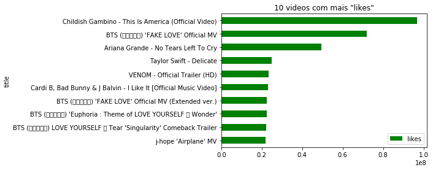

```python
likes.tail(10).plot(kind='barh',x='title',y='likes',title= '10 videos com mais "likes"', color="green")
```

## Top 10 Vídeos com mais visualizações

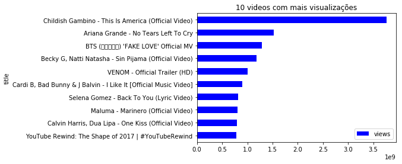

```python
views.tail(10).plot(kind='barh',x='title',y='views',title= '10 videos com mais visualizações', color="b")
```

## Top 10 Vídeos com mais "dislikes"

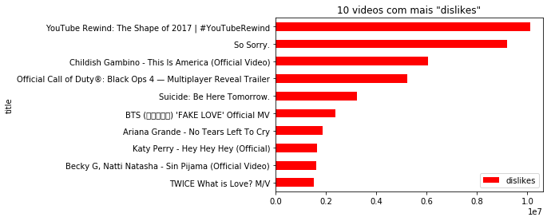

```python
dislikes.tail(10).plot(kind='barh',x='title',y='dislikes',title= '10 videos com mais "dislikes"', color="r")
```

## Top 10 Vídeos mais comentados

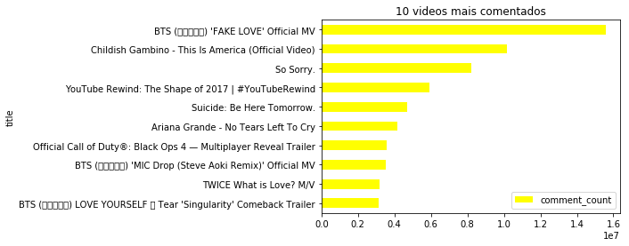

```python
comment_count.tail(10).plot(kind='barh',x='title',y='comment_count',title= '10 videos mais comentados', color="yellow")
```

# Estatística Descritiva

Estatística Descritiva é o ramo que visa sumarizar e descrever qualquer conjunto de dados. Em outras palavras, é aquela estatística que está preocupada em sintetizar os dados de maneira direta, se preocupando menos com variações e intervalos de confiança dos dados. Exemplos de estatísticas descritivas são a média, o desvio padrão e a mediana. A função __describe__ nos traz como resultado os valores sumarizados da estatística descritiva em forma de tabela, como é possível visualizar abaixo.

```python
usvideos.likes.describe()
```

```
count    4.094900e+04
mean     7.426670e+04
std      2.288853e+05
min      0.000000e+00
25%      5.424000e+03
50%      1.809100e+04
75%      5.541700e+04
max      5.613827e+06
Name: likes, dtype: float64
```

```python
usvideos.likes.describe().mean()
```

```
754607.5050805294
```

#### Valor Mínimo (min) de Views, considerando todo o conjunto de dados

```python
usvideos.views.describe().min()
```

```
549.0
```

#### Maior quantidade de comentários encontrados em um único vídeo, considerando todo o conjunto de dados

```python
usvideos.comment_count.describe().max()
```

```
1361580.0
```

## Visualização por métricas estabelecidas

Para visualizarmos os dados por ângulos diferentes, agrupamos a coluna de "publish_month" (Mês de publicação do vídeo) junto com as métricas analisadas (Views, likes, dislikes, comment_count).

```python
month_grp = usvideos.groupby('publish_month')[metrics].sum()
month_grp.reset_index(inplace=True)
```

Abaixo, é feita a visualização dos dados, agregando os resultados da função anterior para visualizar cada métrica.

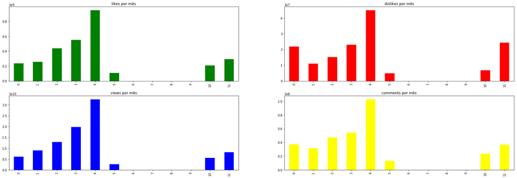

```python
fig = plt.figure(figsize=(30, 10))

ax1 = plt.subplot(2,2,1)
ax2 = plt.subplot(2,2,2)
ax3 = plt.subplot(2,2,3)
ax4 = plt.subplot(2,2,4)


month_grp['likes'].plot(kind='bar',title='likes por mês',ax=ax1, color="green")
month_grp['dislikes'].plot(kind='bar',title='dislikes por mês',ax=ax2, color="red")
month_grp['views'].plot(kind='bar',title='views por mês',ax=ax3, color="blue")
month_grp['comment_count'].plot(kind='bar',title='comments por mês',ax=ax4, color="yellow")
```

Ao analisar os gráficos, principalmente o de views por mês, é possível identificar que no mês de Maio (denominado como "4" no eixo x do gráfico) houve um pico de usuários do YouTube assistindo os vídeos de modo geral.

Abaixo, foi elaborado o mesmo tipo de função, porém, dessa vez agrupamos por "publish_hour" (hora da publicação do vídeo).

```python
hour_grp = usvideos.groupby('publish_hour')[metrics].sum()
hour_grp.reset_index(inplace=True)
```

Essa análise por hora é bem importante, principalmente quando tratamos de Marketing Digital, onde é possível destacar os horários com maior quantidade audiência na plataforma, sendo propícios de investimentos em publicidade.

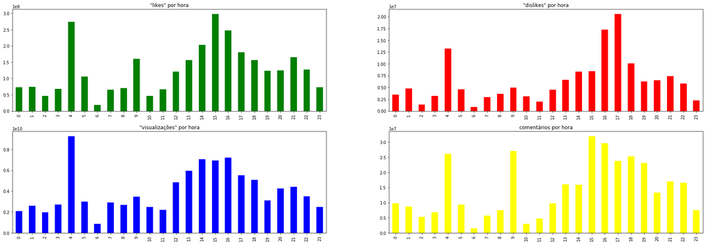

```python
fig = plt.figure(figsize=(30, 10))

ax1 = plt.subplot(2,2,1)
ax2 = plt.subplot(2,2,2)
ax3 = plt.subplot(2,2,3)
ax4 = plt.subplot(2,2,4)


hour_grp['likes'].plot(kind='bar',title='"likes" por hora',ax=ax1, color="green")
hour_grp['dislikes'].plot(kind='bar',title='"dislikes" por hora',ax=ax2, color="red")
hour_grp['views'].plot(kind='bar',title='"visualizações" por hora',ax=ax3, color="blue")
hour_grp['comment_count'].plot(kind='bar',title='comentários por hora',ax=ax4, color="yellow")
```

# Avaliando categorias de vídeos

Analisar a quantidade de views, likes, dislikes e comment_count é importante, porém, analisar o tipo de categoria que está em alta também é muito importante, principalmente se formos tratar com criadores de conteúdo no YouTube. A importância de saber a categoria em alta pode direcioná-lo para um caminho próspero. Uma categoria de um vídeo pode ser definida como o tipo do assunto tratado no vídeo ou o que esperar do vídeo, como por exemplo, um vídeo na categoria de Gaming (Jogos).

As categorias são classificadas por números, e definidas em texto dentro de Key Values em um arquivo JSON. Antes de extraírmos as informações do arquivo JSON, foi elaborada a contagem de cada categoria, levando em consideração o ID.

```python
count_category = usvideos.groupby('category_id').size()
```

A função **size( )** em conjunto com a **groupby( )** nos informa a quantidade de vídeos dentro de cada ID de cada categoria. Abaixo é mostrada a saída dessas funções em conjunto, onde na coluna esquerda da tabela constam os ID's e na coluna direita a quantidade de vídeos dentro daquele ID em específico.

```python
count_category
```

```
category_id
1     2345
2      384
10    6472
15     920
17    2174
19     402
20     817
22    3210
23    3457
24    9964
25    2487
26    4146
27    1656
28    2401
29      57
43      57
dtype: int64
```

Para obtermos os nomes de cada category_id, foi necessário utilizar um arquivo JSON que contém essas informações, sendo necessário acessá-las por meio de Key-values.

```python
uscat = pd.read_json("../data/US_category_id.json")
itens_col = uscat["items"]
i = itens_col.shape[0]
```

Para acessar os nomes dos ID's, foi necessário elaborar um loop, obtendo os nomes e "appendando" em uma lista

```python
ids_l = []
title_l = []
for id_cat in range(i):
    ids = uscat["items"][id_cat]["id"]
    title = uscat["items"][id_cat]["snippet"]["title"]
    ids_l.append(ids)
    title_l.append(title)
```

Com as duas listas prontas, uma de ID e a outra de Tipos (title), foi elaborado um DataFrame de categorias (df_cat), para indexar cada ID com seu respectivo nome.

```python
df_cat = pd.DataFrame(title_l, columns=["category"])
df_cat["ids"] = ids_l
df_cat
```

|  | category | ids |
| --- | --- | --- |
| 0 | Film & Animation | 1 |
| 1 | Autos & Vehicles | 2 |
| 2 | Music | 10 |
| 3 | Pets & Animals | 15 |
| 4 | Sports | 17 |
| 5 | Short Movies | 18 |
| 6 | Travel & Events | 19 |
| 7 | Gaming | 20 |
| 8 | Videoblogging | 21 |
| 9 | People & Blogs | 22 |
| 10 | Comedy | 23 |
| 11 | Entertainment | 24 |
| 12 | News & Politics | 25 |
| 13 | Howto & Style | 26 |
| 14 | Education | 27 |
| 15 | Science & Technology | 28 |
| 16 | Nonprofits & Activism | 29 |
| 17 | Movies | 30 |
| 18 | Anime/Animation | 31 |
| 19 | Action/Adventure | 32 |
| 20 | Classics | 33 |
| 21 | Comedy | 34 |
| 22 | Documentary | 35 |
| 23 | Drama | 36 |
| 24 | Family | 37 |
| 25 | Foreign | 38 |
| 26 | Horror | 39 |
| 27 | Sci-Fi/Fantasy | 40 |
| 28 | Thriller | 41 |
| 29 | Shorts | 42 |
| 30 | Shows | 43 |
| 31 | Trailers | 44 |

```python
series_values = count_category.sort_values(ascending=False)
series_count = series_values.head(5)
category_df = pd.DataFrame(series_count)
category_df["categoria"] = ["Entretenimento", "Musica", "Como Fazer & Estilos", "Comedia", "Pessoas & Blogs"]
category_df
```

| category_id | 0 | categoria |
| --- | --- | --- |
| 24 | 9964 | Entretenimento |
| 10 | 6472 | Musica |
| 26 | 4146 | Como Fazer & Estilos |
| 23 | 3457 | Comedia |
| 22 | 3210 | Pessoas & Blogs |

O ranking apresentado acima é das 5 categorias com maior quantidade de vídeos.

```
([0, 1, 2, 3, 4], <a list of 5 Text xticklabel objects>)
```

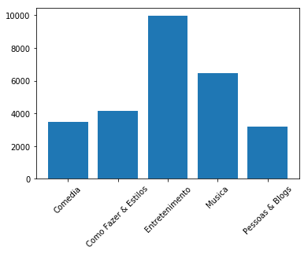

```python
plt.bar(category_df["categoria"],category_df[0])
plt.xticks(rotation=45)
```

# Conclusão

*Este projeto é parte da disciplina de Laboratório de Redes, apresentado no 6º semestre do curso superior em Análise e Desenvolvimento de Sistemas da Fatec-Cruzeiro.*

*Apresentado em __Novembro de 2018__*

## < [Voltar](https://almirgiornes.github.io/)